# Week 2 Assigment

laknath Gunathilake

January 15, 2020

```r
source("http://www.openintro.org/stat/data/cdc.R")
```

## NOW ON YOUR OWN

### 1. Make a scatterplot of weight versus desired weight. Describe the relationship between these two variables.

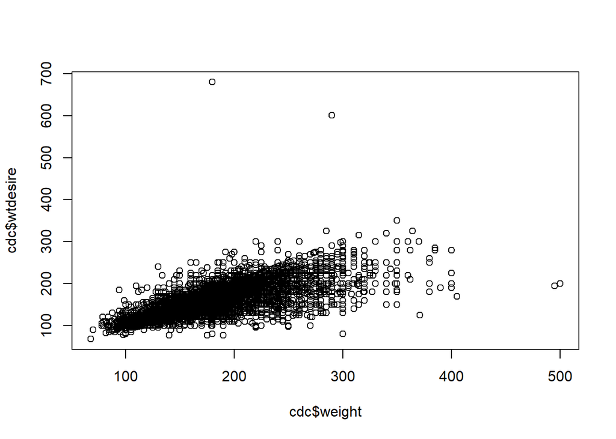

```r
plot( cdc$weight , cdc$wtdesire  )
```

The actual weight and desired weight seem to have a strong association between 75 and 275lb. However, this relationship is weaker for those who are above 300lb.This would make sense since, we can assume that those who are overweight/obese hope to loose weight, and thus have a desired weight that is lower than their current weight.

### 2. Let’s consider a new variable: the difference between desired weight (wtdesire) and current weight (weight).

Create this new variable by subtracting the two columns in the data frame and assigning them to a new object called wdiff.

```r
  wdiff = cdc$wtdesire - cdc$weight
```

### 3. What type of data is wdiff? If an observation wdiff is 0, what does this mean about the person’s weight and desired weight What if wdiff is positive or negative?

```r
    class(wdiff)
```

```
## [1] "integer"
```

- The class of Data is an Integer
- the actual weight and the desired weight are the same:or a person weighs exactly how much they want to weigh.
- negative wdiff=This means that the actual weight is higher than desired weight (They would hope to loose weight)
- positive wdiff=This means that the the actual weight is lower than the desired weight (they would hope to gain weight)

### 4. Describe the distribution of wdiff in terms of its center, shape, and spread, including any plots you use.

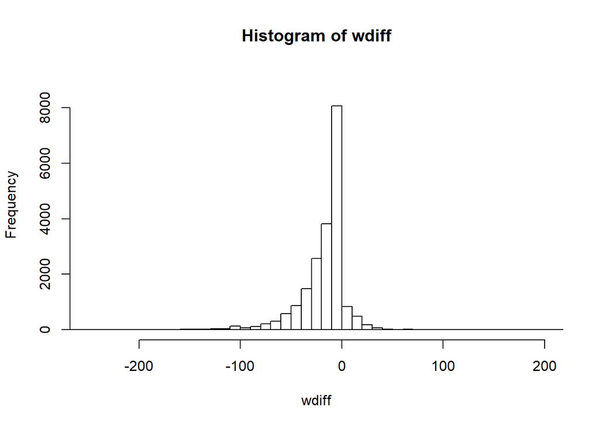

```r
    hist(wdiff,breaks = 75,xlim = c(-250,200),ylim = c(0,9000))
```

```r
    mean(wdiff)
```

```
## [1] -14.5891
```

```r
    median(wdiff)
```

```
## [1] -10
```

```r
    min(wdiff)
```

```
## [1] -300
```

```r
    max(wdiff)
```

```
## [1] 500
```

```r
    library(moments)
    skewness(wdiff)
```

```
## [1] -1.447632
```

### 5.Using mumerical summaries and a side-by-side box plot, determine if men tend to view their weight differently than women.

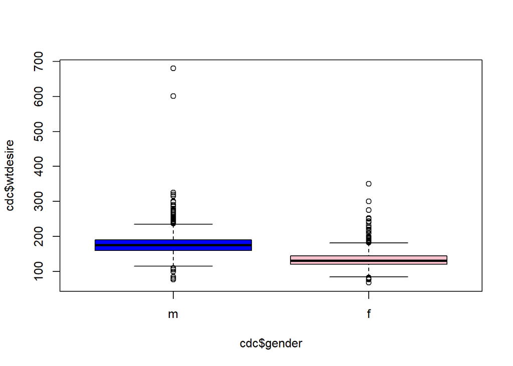

```r
  boxplot(cdc$wtdesire~cdc$gender,col=(c("blue","pink")))
```

```r
  tapply(cdc$wtdesire,cdc$gender, mean, na.rm=TRUE)
```

```
##        m        f
## 178.6166 133.5150
```

```r
  tapply(cdc$wtdesire,cdc$gender, median, na.rm=TRUE)
```

```
##   m   f
## 175 130
```

- It is evident that men tend to have a higher desired weight on average than women. On average, men seem to be want to be around 178lb while women hope to be around the 133lb mark.

### 6.Now it’s time to get creative. Find the mean and standard deviation of weight and determine what proportion of the weights are within one standard deviation of the mean.

```r
mean(cdc$weight)
```

```
## [1] 169.683
```

```r
sd(cdc$weight)
```

```
## [1] 40.08097
```

```r
within_one_negative<-mean(cdc$weight)-sd(cdc$weight)
within_one_positive<-mean(cdc$weight)+sd(cdc$weight)

within_one_sd<-cdc$weight[ cdc$weight >= within_one_negative & cdc$weight <= within_one_positive]
length(within_one_sd)/length(cdc$weight)*100
```

```
## [1] 70.76
```

- 70 percents of the weights are within one standard deviation of the mean weight which is169.68295